# Visualisierung – Wann welche Darstellung?

### Exploration anhand des Titanic-Datensatzes

**Leitfrage:** Welche Visualisierung ist für welche Fragestellung geeignet – und warum?

Datensatz *Quelle*: https://github.com/mwaskom/seaborn-data/blob/master/titanic.csv Bereitgestellt von: https://seaborn.pydata.org/

Jupyter Notebook von: Devin Rohrer

```python
import seaborn as sns
import matplotlib.pyplot as plt

# Originaler titanic datensatz
df = sns.load_dataset('titanic')

# Styling
sns.set_theme(style='whitegrid', palette='muted')
plt.rcParams['figure.dpi'] = 110

print(f"Datensatz: {df.shape[0]} Passagiere, {df.shape[1]} Merkmale")
print(f"Überlebensrate gesamt: {df['survived'].mean():.1%}")

# Die ersten 5 Zeilen ausgeben
df.head()
```

```
Datensatz: 891 Passagiere, 15 Merkmale
Überlebensrate gesamt: 38.4%
```

|  | survived | pclass | sex | age | sibsp | parch | fare | embarked | class | who | adult_male | deck | embark_town | alive | alone |
| --- | --- | --- | --- | --- | --- | --- | --- | --- | --- | --- | --- | --- | --- | --- | --- |
| 0 | 0 | 3 | male | 22.0 | 1 | 0 | 7.2500 | S | Third | man | True | NaN | Southampton | no | False |
| 1 | 1 | 1 | female | 38.0 | 1 | 0 | 71.2833 | C | First | woman | False | C | Cherbourg | yes | False |
| 2 | 1 | 3 | female | 26.0 | 0 | 0 | 7.9250 | S | Third | woman | False | NaN | Southampton | yes | True |
| 3 | 1 | 1 | female | 35.0 | 1 | 0 | 53.1000 | S | First | woman | False | C | Southampton | yes | False |
| 4 | 0 | 3 | male | 35.0 | 0 | 0 | 8.0500 | S | Third | man | True | NaN | Southampton | no | True |

# 1. Visualisierung: Histogramm

#### **Wann ein Histogramm?**

Immer dann, wenn man eine **einzelne numerische Variable** hat und verstehen will, wie die Werte verteilt sind – wo die Masse liegt, ob es Ausreißer gibt, ob die Verteilung symmetrisch oder schief ist.

*Frage:* Wie ist das Alter der Passagiere verteilt?

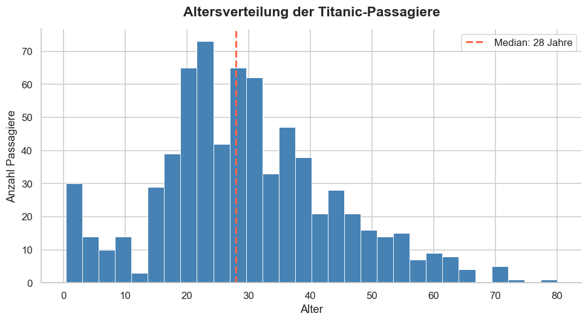

```
Median: 28 Jahre | Mittelwert: 29.7 Jahre
Jüngster: 0 Jahre | Ältester: 80 Jahre
```

```python
fig, ax = plt.subplots(figsize=(9, 5))

# Histogramm erstellen:
ax.hist(df['age'], bins=30, color='steelblue', edgecolor='white', linewidth=0.6)

# Median berechnen und visualisieren:
median_age = df['age'].median()
ax.axvline(median_age, color='tomato', linestyle='--', linewidth=2,
           label=f'Median: {median_age:.0f} Jahre')

ax.set_title('Altersverteilung der Titanic-Passagiere', fontsize=15, fontweight='bold', pad=14)
ax.set_xlabel('Alter', fontsize=12)
ax.set_ylabel('Anzahl Passagiere', fontsize=12)
ax.legend(fontsize=11)

sns.despine()
plt.tight_layout()
plt.show()

print(f"Median: {df['age'].median():.0f} Jahre | Mittelwert: {df['age'].mean():.1f} Jahre")
print(f"Jüngster: {df['age'].min():.0f} Jahre | Ältester: {df['age'].max():.0f} Jahre")
```

**Beobachtung:** Die meisten Passagiere waren zwischen 20 und 40 Jahre alt. Es gibt einen kleinen Peak bei Kindern und einige ältere Passagiere als Ausreißer.

**Wann kein Histogramm?** Wenn man Gruppen miteinander vergleichen möchte – dafür ist der Boxplot deutlich besser geeignet (s. Visualisierung 3).

# 2. Visualisierung: Balkendiagramm

#### **Wann ein Balkendiagramm?**

Wenn man **kategorische Gruppen vergleicht** – z.B. Klassen, Geschlecht, Herkunft. Balken machen Unterschiede zwischen Kategorien direkt und präzise ablesbar.

*Frage:* Wie unterscheidet sich die Überlebensrate nach Reiseklasse und Geschlecht?

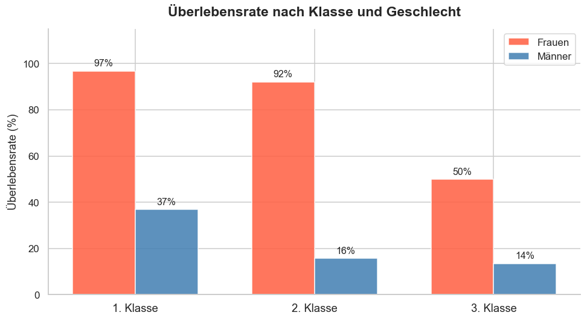

```python
survival = df.groupby(['pclass', 'sex'])['survived'].mean().reset_index()
survival['survived_pct'] = survival['survived'] * 100

fig, ax = plt.subplots(figsize=(9, 5))

colors_sex = {'male': 'steelblue', 'female': 'tomato'}
labels_sex = {'male': 'Männer', 'female': 'Frauen'}
x = [0, 1, 2]
width = 0.35

for i, (sex, grp) in enumerate(survival.groupby('sex')):
    offset = -width / 2 if i == 0 else width / 2
    bars = ax.bar([xi + offset for xi in x], grp['survived_pct'],
                  width=width, label=labels_sex[sex], color=colors_sex[sex], alpha=0.88)
    for bar in bars:
        h = bar.get_height()
        ax.text(bar.get_x() + bar.get_width() / 2, h + 1.2, f'{h:.0f}%',
                ha='center', va='bottom', fontsize=10.5)

ax.set_xticks(x)
ax.set_xticklabels(['1. Klasse', '2. Klasse', '3. Klasse'], fontsize=12)
ax.set_ylabel('Überlebensrate (%)', fontsize=12)
ax.set_ylim(0, 115)
ax.set_title('Überlebensrate nach Klasse und Geschlecht', fontsize=15, fontweight='bold', pad=14)
ax.legend(fontsize=11)

sns.despine()
plt.tight_layout()
plt.show()
```

**Beobachtung:** Frauen überlebten in allen Klassen deutlich häufiger. Klassenunterschiede sind stark erkennbar. **Warum kein Tortendiagramm?** Tortendiagramme eignen sich nur für Anteile eines Ganzen mit wenigen Kategorien. Für Gruppenvergleiche sind Balken fast immer besser – Längen lassen sich viel präziser ablesen als Winkel.

# 3. Visualisierung: Boxplot

#### **Wann ein Boxplot?**

Wenn man eine **numerische Variable über mehrere Gruppen hinweg vergleichen** möchte. Der Boxplot zeigt Median, Streuung (IQR) und Ausreißer auf einmal – ein Histogramm könnte das nur mit mehreren überlagerten Grafiken.

*Frage:* Unterscheidet sich das Alter zwischen Überlebenden und Nicht-Überlebenden?

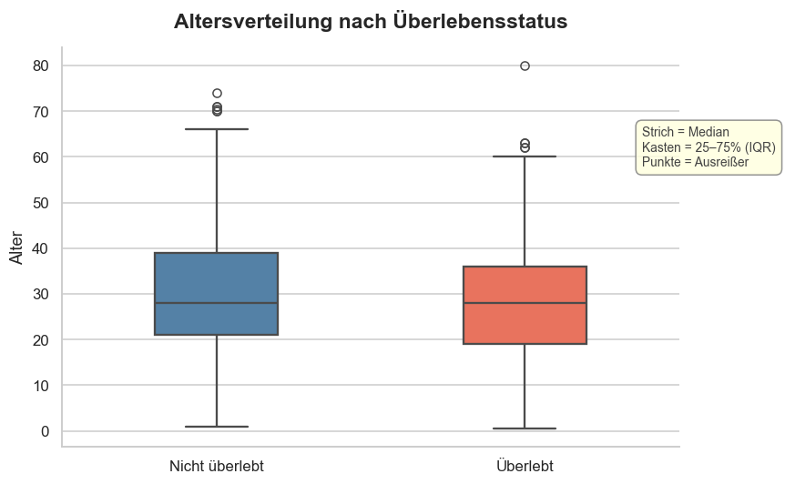

```
Nicht überlebt: Median = 28.0 | IQR = 21.0 – 39.0
Überlebt: Median = 28.0 | IQR = 19.0 – 36.0
```

```python
df_box = df.copy()
df_box['Überleben'] = df_box['survived'].map({0: 'Nicht überlebt', 1: 'Überlebt'})

fig, ax = plt.subplots(figsize=(8, 5))

sns.boxplot(
    data=df_box, x='Überleben', y='age',
    hue='Überleben', legend=False,
    palette={'Nicht überlebt': 'steelblue', 'Überlebt': 'tomato'},
    width=0.4, linewidth=1.5, ax=ax
)

ax.set_title('Altersverteilung nach Überlebensstatus', fontsize=15, fontweight='bold', pad=14)
ax.set_xlabel('', fontsize=12)
ax.set_ylabel('Alter', fontsize=12)

ax.text(1.38, 58,
        'Strich = Median\nKasten = 25–75% (IQR)\nPunkte = Ausreißer',
        fontsize=9, color='#444',
        bbox=dict(boxstyle='round,pad=0.5', facecolor='lightyellow',
                  edgecolor='gray', alpha=0.85))

sns.despine()
plt.tight_layout()
plt.show()

for gruppe, data in df_box.groupby('Überleben'):
    print(f"{gruppe}: Median = {data['age'].median():.1f} | IQR = {data['age'].quantile(0.25):.1f} – {data['age'].quantile(0.75):.1f}")
```

**Beobachtung:** Der Median ist bei beiden Gruppen ähnlich. Kinder tauchen leicht häufiger unter den Überlebenden auf.

**Wann kein Boxplot?** Bei sehr kleinen Stichproben (< 20 Werte) – dann ist ein Strip- oder Swarmplot ehrlicher, weil er die einzelnen Datenpunkte zeigt.

# 4. Visualisierung: Scatterplot

#### **Wann ein Scatterplot?**

Wenn man den **Zusammenhang zwischen zwei numerischen Variablen** untersucht. Durch Farbe kann man gleichzeitig eine dritte (kategorische) Variable einbinden – so werden drei Dimensionen in einer Grafik sichtbar.

*Frage:* Gibt es einen Zusammenhang zwischen Alter, Fahrpreis und Überleben?

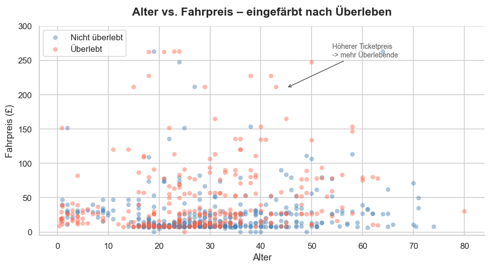

```python
df_scatter = df.copy()
df_scatter['Überleben'] = df_scatter['survived'].map({0: 'Nicht überlebt', 1: 'Überlebt'})

fig, ax = plt.subplots(figsize=(9, 5))

colors_map = {'Nicht überlebt': 'steelblue', 'Überlebt': 'tomato'}
for gruppe, grp in df_scatter.groupby('Überleben'):
    ax.scatter(grp['age'], grp['fare'], label=gruppe,
               alpha=0.45, s=35, color=colors_map[gruppe], edgecolors='none')

ax.set_title('Alter vs. Fahrpreis – eingefärbt nach Überleben', fontsize=15, fontweight='bold', pad=14)
ax.set_xlabel('Alter', fontsize=12)
ax.set_ylabel('Fahrpreis (£)', fontsize=12)
ax.set_ylim(-5, 300)
ax.legend(fontsize=11)

ax.annotate('Höherer Ticketpreis \n-> mehr Überlebende',
            xy=(45, 210), xytext=(54, 255),
            fontsize=9, color='#555',
            arrowprops=dict(arrowstyle='->', color='#555'))

sns.despine()
plt.tight_layout()
plt.show()
```

**Beobachtung:** Passagiere mit teuren Tickets (oben) überlebten häufiger – erkennbar an der höheren Dichte roter Punkte. Bei günstigen Tickets dominieren blaue Punkte.

**Wann kein Scatterplot?** Bei kategorischen Variablen auf beiden Achsen – dann lieber eine Heatmap oder ein Balkendiagramm.

## Anhang – Visualisierung 5: Heatmap

### Korrelationsmatrix der numerischen Variablen

**Wann eine Heatmap?**  
Wenn man schnell einen **Überblick über Zusammenhänge zwischen vielen Variablen** bekommen möchte. Besonders nützlich am Anfang einer explorativen Analyse – als Orientierungshilfe, bevor man sich auf einzelne Variablen fokussiert.

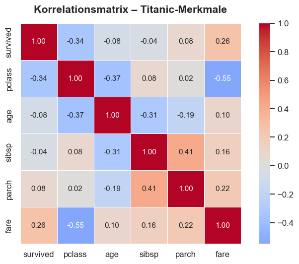

```
Stärkste Korrelationen mit 'survived':
pclass   -0.338481
fare      0.257307
parch     0.081629
age      -0.077221
sibsp    -0.035322
```

```python
cols = ['survived', 'pclass', 'age', 'sibsp', 'parch', 'fare']
corr = df[cols].corr()

fig, ax = plt.subplots(figsize=(7, 5))

sns.heatmap(corr, annot=True, fmt='.2f', cmap='coolwarm', center=0,
            linewidths=0.5, square=True, ax=ax, annot_kws={'size': 10})

ax.set_title('Korrelationsmatrix – Titanic-Merkmale', fontsize=14, fontweight='bold', pad=14)
plt.tight_layout()
plt.show()

print("Stärkste Korrelationen mit 'survived':")
print(corr['survived'].drop('survived').sort_values(key=abs, ascending=False).to_string())
```

**Beobachtung:** `pclass` hat die stärkste (negative) Korrelation mit `survived`. `fare` korreliert positiv. Das deckt sich mit dem, was wir im Scatterplot gesehen haben – die Heatmap gibt den schnellen Überblick.

## Anhang – Visualisierung 6: Pairplot

Der folgende Python-Code im Anhang für Visualisierung Nr.6 wurde mithilfe von KI generiert und überprüft. Modell: Claude Sonnet 4.6.

### Alle numerischen Variablen auf einen Blick

**Wann ein Pairplot?**  
Nur in der **frühen Explorationsphase**, wenn man noch gar nicht weiß, welche Variablen interessant sind. Für Berichte oder Präsentationen ist er meist zu unübersichtlich – er ist ein Werkzeug für den Analysten, nicht für das Publikum.

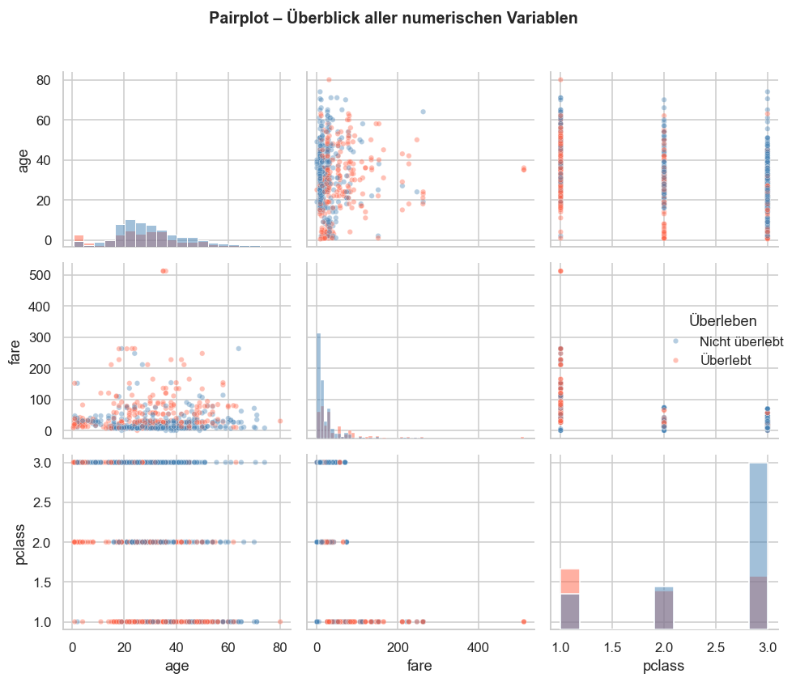

```python
"""
Der folgende Code für das Pairplot wurde mit Hilfe von KI generiert.
Modell: Claude 4.6 Sonnet
"""

df_pair = df[['survived', 'age', 'fare', 'pclass']].copy()
df_pair['Überleben'] = df_pair['survived'].map({0: 'Nicht überlebt', 1: 'Überlebt'})

g = sns.pairplot(
    df_pair[['age', 'fare', 'pclass', 'Überleben']],
    hue='Überleben',
    palette={'Nicht überlebt': 'steelblue', 'Überlebt': 'tomato'},
    diag_kind='hist',
    plot_kws={'alpha': 0.4, 's': 18}
)

g.figure.suptitle('Pairplot – Überblick aller numerischen Variablen',
                   y=1.02, fontsize=13, fontweight='bold')
plt.tight_layout()
plt.show()
```

**Fazit:** Der Pairplot ist ein Tool für die eigene Analyse – nicht für die Kommunikation von Ergebnissen. Sobald man weiß, was interessant ist, greift man auf gezielte Einzelplots zurück.

## Zusammenfassung:

| Ziel | Visualisierung |
| --- | --- |
| Verteilung **einer** numerischen Variable | **Histogramm** |
| Unterschiede nach **Kategorien** | **Balkendiagramm** |
| Verteilung zwischen **Gruppen** vergleichen | **Boxplot** |
| **Zusammenhänge** zwischen zwei Variablen erkennen | **Scatterplot** |
| **Korrelation** zweier Variablen | **Heatmap** |
| Interessante Variablen entdecken | **Pairplot** (nur Exploration) |